# Lab 5 - Time-varying productivity of salmon

Dynamic Linear Models (DLMs)

Eric French, Madison Heller-Shipley, Karl Veggerby

May 11, 2023

# Data

## Load the data

```r
## library(devtools)
## Windows users will likely need to set this
## Sys.setenv("R_REMOTES_NO_ERRORS_FROM_WARNINGS" = "true")
#devtools::install_github("nwfsc-timeseries/atsalibrary") already installed

## get data
data(KvichakSockeye, package="atsalibrary")
SR_data <- KvichakSockeye
head(SR_data)
```

```
## # A tibble: 6 × 5
## # Groups:   brood_year [6]
##   brood_year spawners recruits pdo_summer_t2 pdo_winter_t2
##        <dbl>    <dbl>    <dbl>         <dbl>         <dbl>
## 1       1952       NA    20200         -2.79         -1.68
## 2       1953       NA      593         -1.2          -1.05
## 3       1954       NA      799         -1.85         -1.25
## 4       1955       NA     1500         -0.6          -0.68
## 5       1956     9440    39000         -0.5          -0.31
## 6       1957     2840     4090         -2.36         -1.78
```

The data are a dataframe with columns for brood year (`brood_year`), number of spawners (`spawners`), number of recruits (`recruits`) and PDO at year $t-2$ in summer (`pdo_summer_t2`) and in winter (`pdo_winter_t2`).

### Plot Biological Data

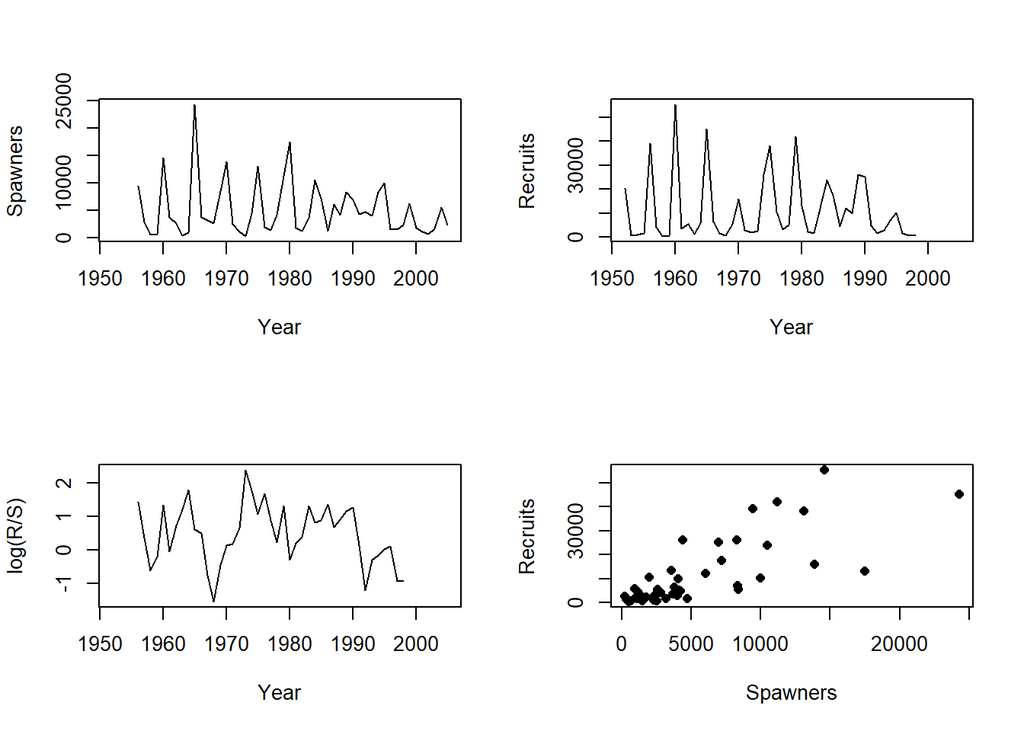

```r
par(mfrow=c(2,2))
plot(SR_data$brood_year, SR_data$spawners, type= "l", xlab = "Year", ylab = "Spawners")
plot(SR_data$brood_year, SR_data$recruits, type= "l", xlab = "Year", ylab = "Recruits")
plot(SR_data$brood_year, log(SR_data$recruits/SR_data$spawners) , xlab = "Year", ylab = "log(R/S)", type= "l")
plot(SR_data$spawners, SR_data$recruits, xlab = "Spawners", ylab = "Recruits", pch = 16)
```

### Plot Environmental Data

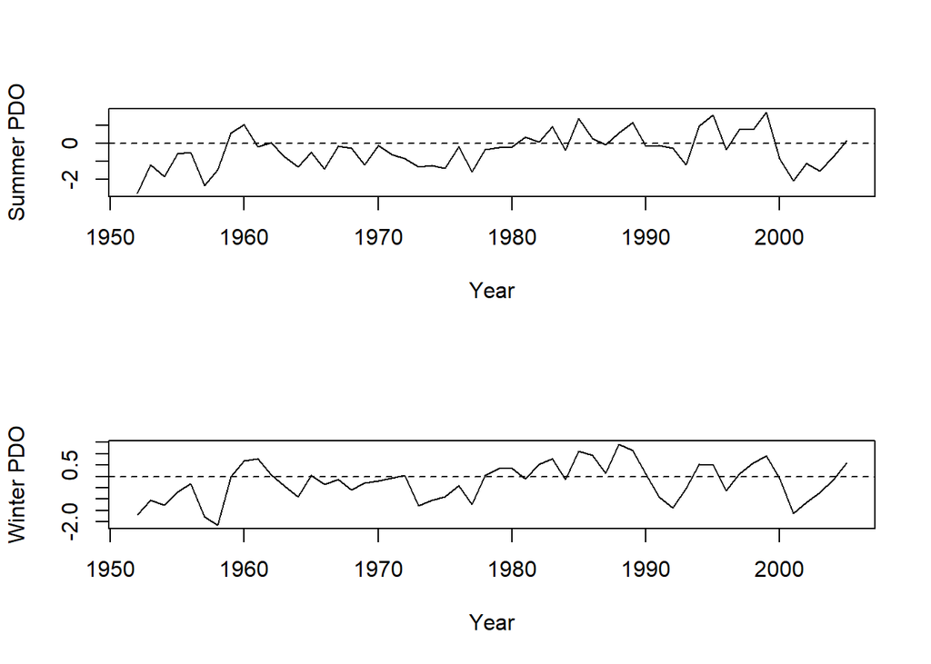

```r
par(mfrow=c(2,1))
plot(SR_data$brood_year, SR_data$pdo_summer_t2, type= "l", xlab = "Year", ylab = "Summer PDO")
abline(h=0, lty = 2)
plot(SR_data$brood_year, SR_data$pdo_winter_t2, type= "l", xlab = "Year", ylab = "Winter PDO")
abline(h=0, lty= 2)
```

## Wrangle the data

```r
## shrink the window of years so the response variable will have a full set of values
SR_dat_short <- SR_data[SR_data[,"brood_year"] >= 1956 & SR_data[,"brood_year"] <= 1998, ]

#Create a column for the response variable
SR_dat_short$Yt <- log(SR_dat_short$recruits/SR_dat_short$spawners) #Yt represents log of recruits over spawners.

#Create the observation matrix
Yt <- t(SR_dat_short$Yt)

#determines number of elements
TT <- nrow(SR_dat_short)
```

# General tasks

Use the information and data in the previous section to answer the following questions. Note that if any model is not converging, then you will need to increase the `maxit` parameter in the `control` argument/list that gets passed to `MARSS()`. For example, you might try `control=list(maxit=2000)`.

# Methods

## Reduced Ricker’s Model

1. Begin by fitting a reduced form of Ricker’s model that includes only a time-varying level ($\alpha_t$) and observation error ($v_t$). That is,

$$\begin{align*}
\text{log}(R_t) &= \alpha_t + \text{log}(S_t) + v_t \\
\text{log}(R_t/S_t) &= \alpha_t + v_t
\end{align*}$$

This model assumes no density-dependent survival in that the number of recruits is an ascending function of spawners. Plot the ts of $\alpha_t$ and note the AICc for this model. Also plot appropriate model diagnostics.

```r
#create the model params for reduced Ricker's model
Z <- array(NA,c(1,1,TT))
Z[1,1,] <- c(1)

modlist <- list( # All other arguaments are left as default
  Z = Z,
  U = "zero",
  A = "zero",
  B = "identity"
)

reduced_Rick <- MARSS(Yt, model = modlist)
```

```
## Success! abstol and log-log tests passed at 24 iterations.
## Alert: conv.test.slope.tol is 0.5.
## Test with smaller values (<0.1) to ensure convergence.
##
## MARSS fit is
## Estimation method: kem
## Convergence test: conv.test.slope.tol = 0.5, abstol = 0.001
## Estimation converged in 24 iterations.
## Log-likelihood: -51.87179
## AIC: 109.7436   AICc: 110.359
##
##       Estimate
## R.R      0.211
## Q.Q      0.303
## x0.x0    1.002
## Initial states (x0) defined at t=0
##
## Standard errors have not been calculated.
## Use MARSSparamCIs to compute CIs and bias estimates.
```

Results: The AICc of this model is 110.36, state plots and residuals are below

### Model and State Plots

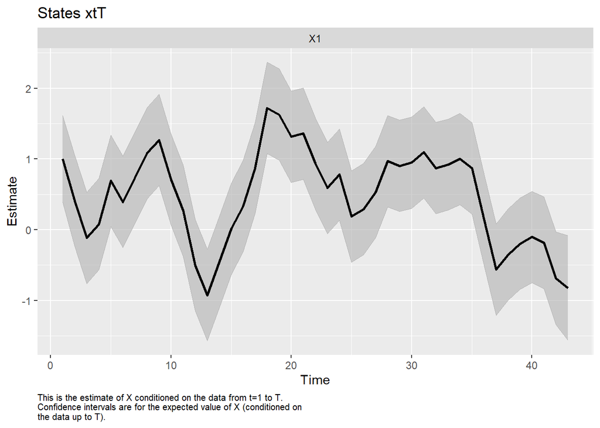

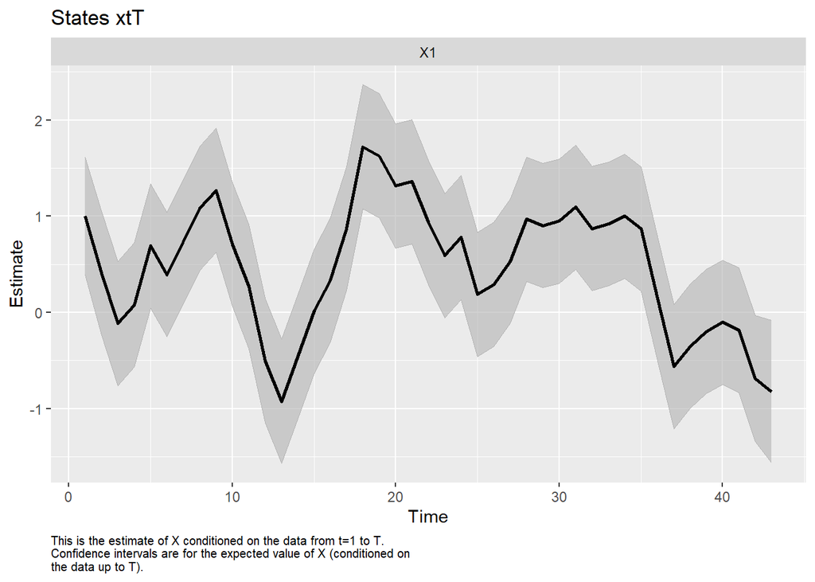

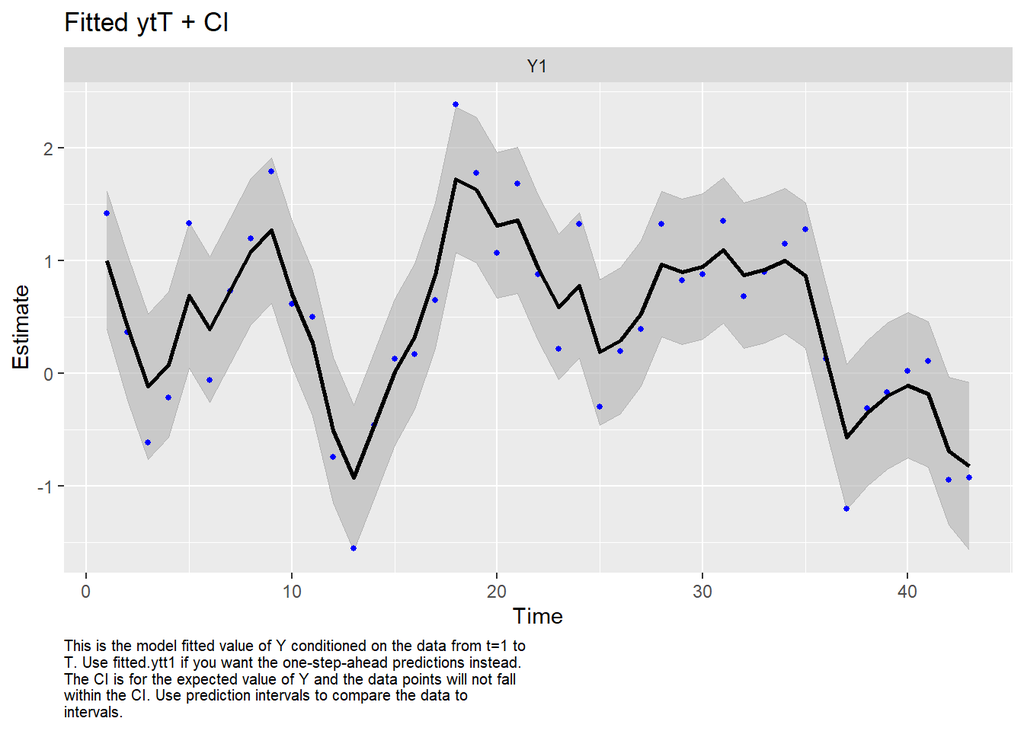

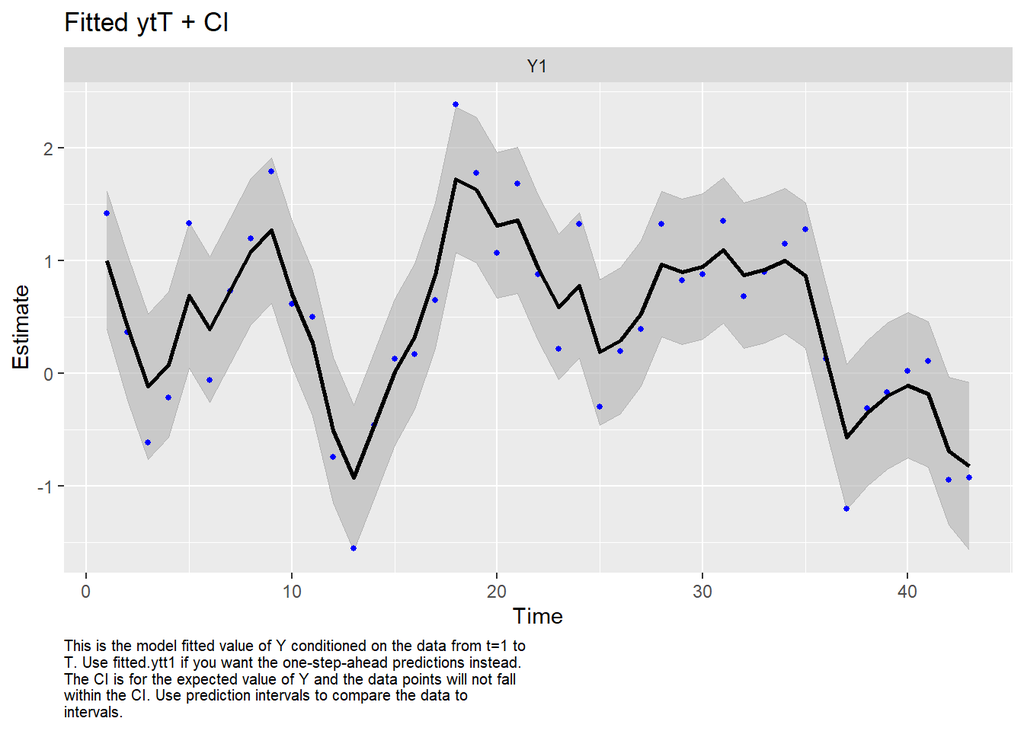

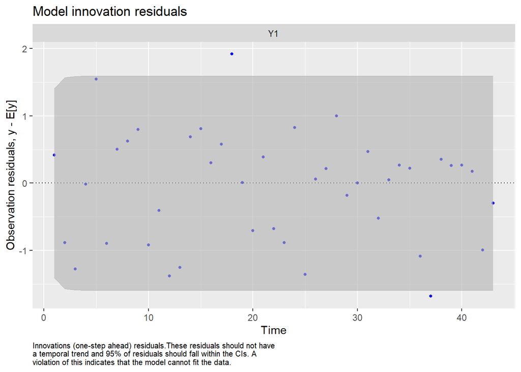

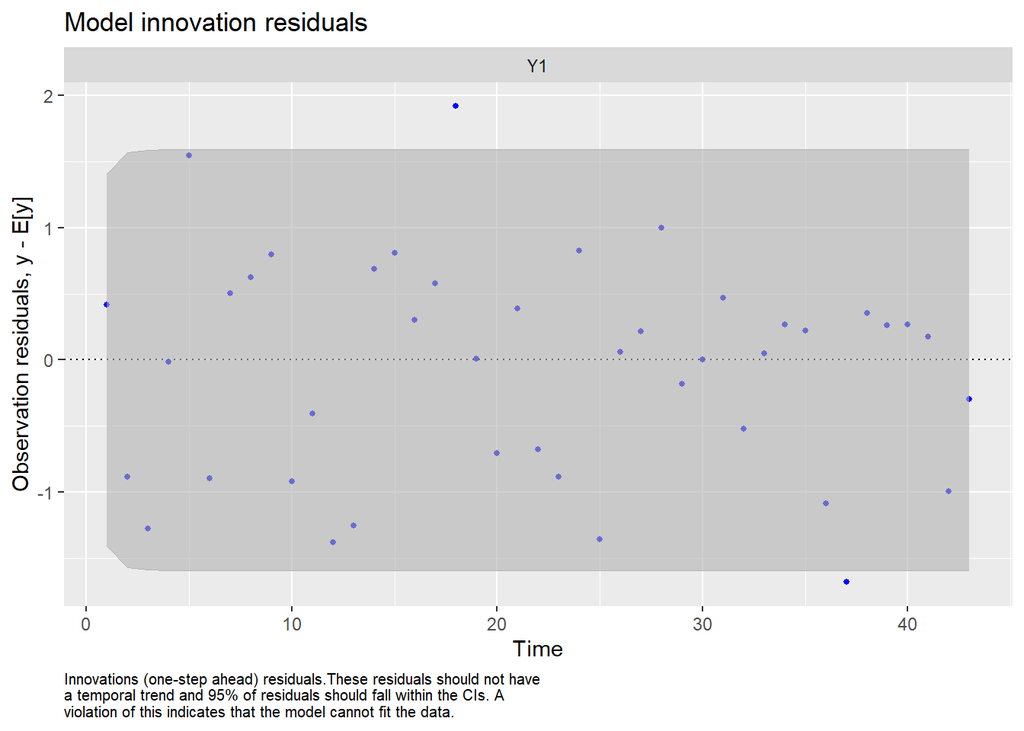

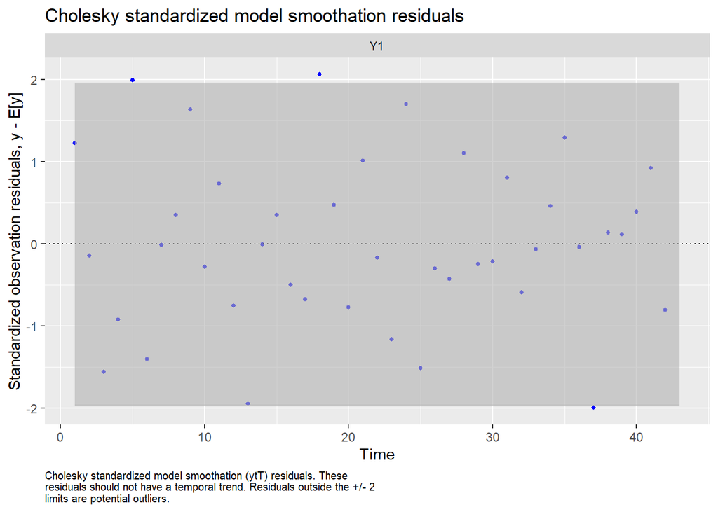

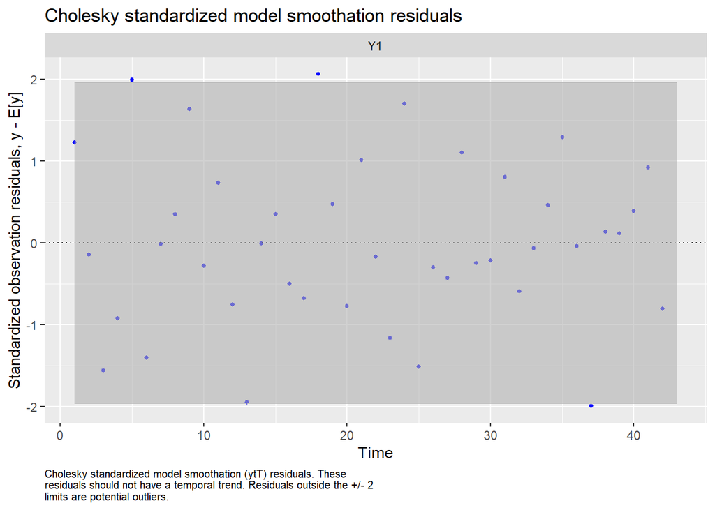

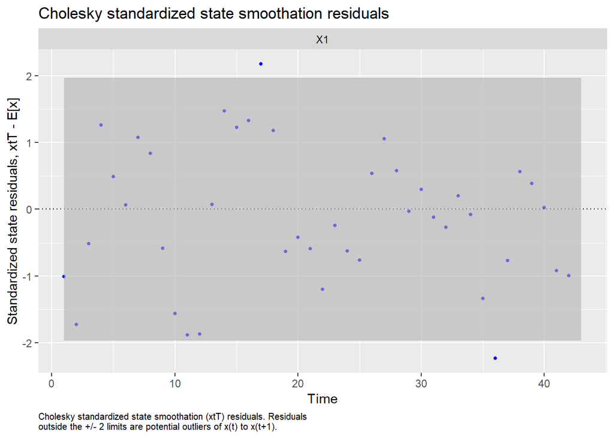

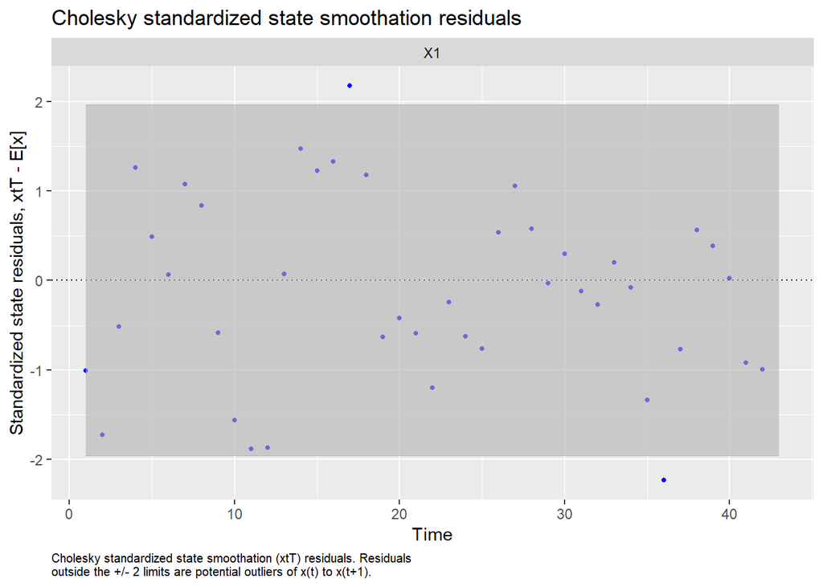

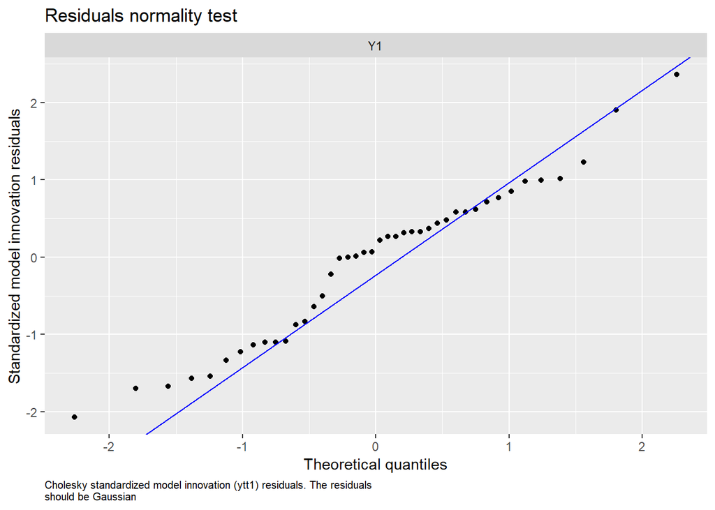

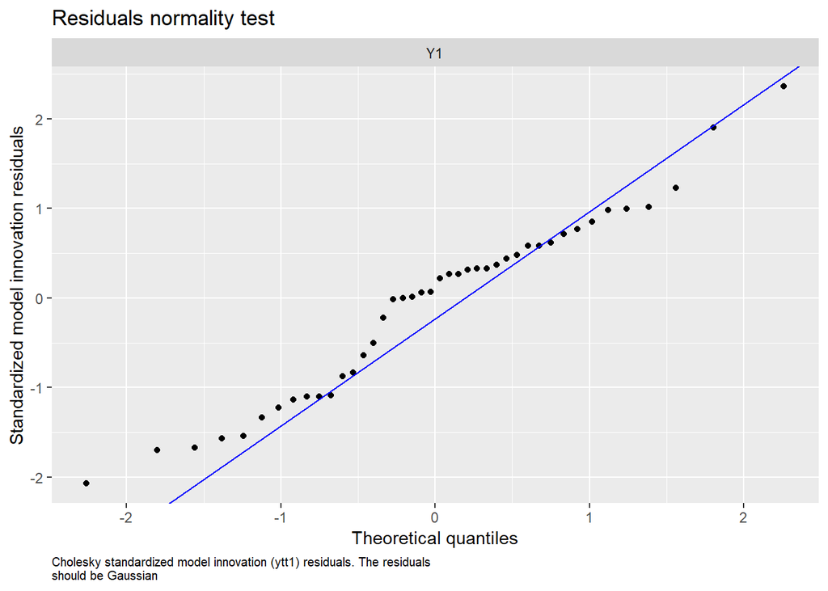

[4 more figures not shown]

```r
autoplot(reduced_Rick, silent = TRUE)
```

## Full Ricker’s Model with Static Spawner Effect

2. Fit the full Ricker model with a time-varying intercept and a static effect of spawners. For this model, obtain the time series of $\alpha_t$, which is an estimate of the stock productivity in the absence of density-dependent effects. How do these estimates of productivity compare to those from the previous question? Plot the ts of $\alpha_t$ and note the AICc for this model. Also plot appropriate model diagnostics.

$$\begin{align*}
\text{log}(R_t/S_t) = \alpha_t - bS_t + v_t \\
\alpha_t = \alpha_{t-1} + w_t
\end{align*}$$

```r
#create the model params for the full Ricker's model
Z <- array(NA,c(1,2,TT)) # the array has 2 elements now
Z[1,1,] <- c(1)
Z[1,2,] <- SR_dat_short$spawners

modlist <- list( # All other arguments are left as default
  Z = Z,
  U = "zero",
  A = "zero",
  B = "identity",
  Q = ldiag(list("q1",0)) # creates a custom Q matrix with zero variance for the spawner effect... I think
)

full_Rick <- MARSS(Yt, model = modlist, inits = list(x0 = matrix(c(0),2,1))) # added inits list due to marss error
```

```
## Success! abstol and log-log tests passed at 26 iterations.
## Alert: conv.test.slope.tol is 0.5.
## Test with smaller values (<0.1) to ensure convergence.
##
## MARSS fit is
## Estimation method: kem
## Convergence test: conv.test.slope.tol = 0.5, abstol = 0.001
## Estimation converged in 26 iterations.
## Log-likelihood: -51.80921
## AIC: 111.6184   AICc: 112.6711
##
##       Estimate
## R.R   0.217557
## Q.q1  0.293165
## x0.X1 0.936822
## x0.X2 0.000007
## Initial states (x0) defined at t=0
##
## Standard errors have not been calculated.
## Use MARSSparamCIs to compute CIs and bias estimates.
```

Result: AICC is 112.67, higher than the previous model after multiple attempts at different x0 values. each one resulted in the same model. The increase in AICc is likely driven by an increase in parameters by allowing density dependency and time variation in the intercepts.

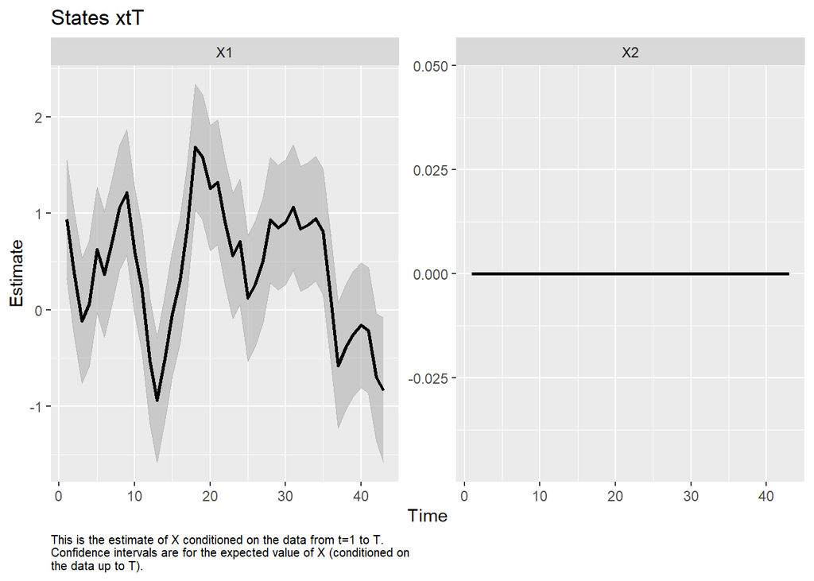

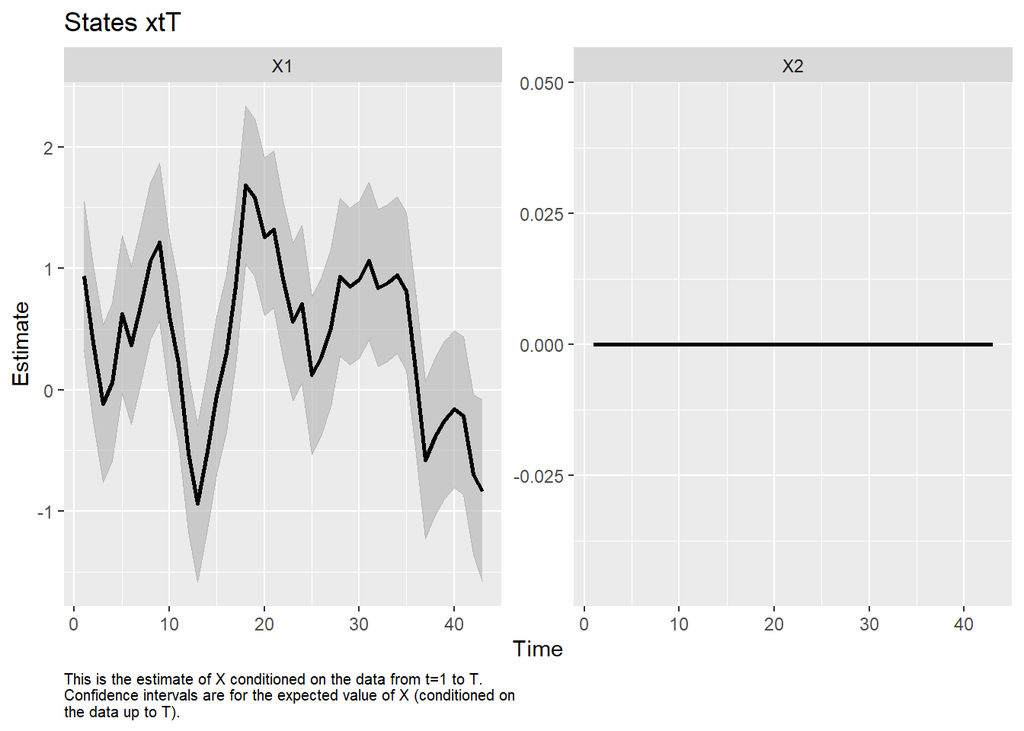

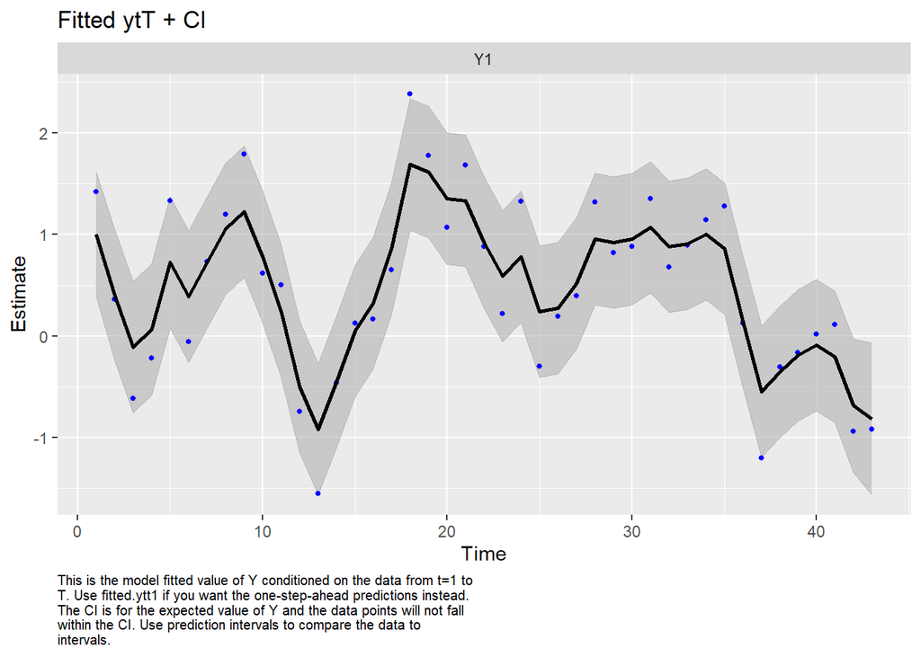

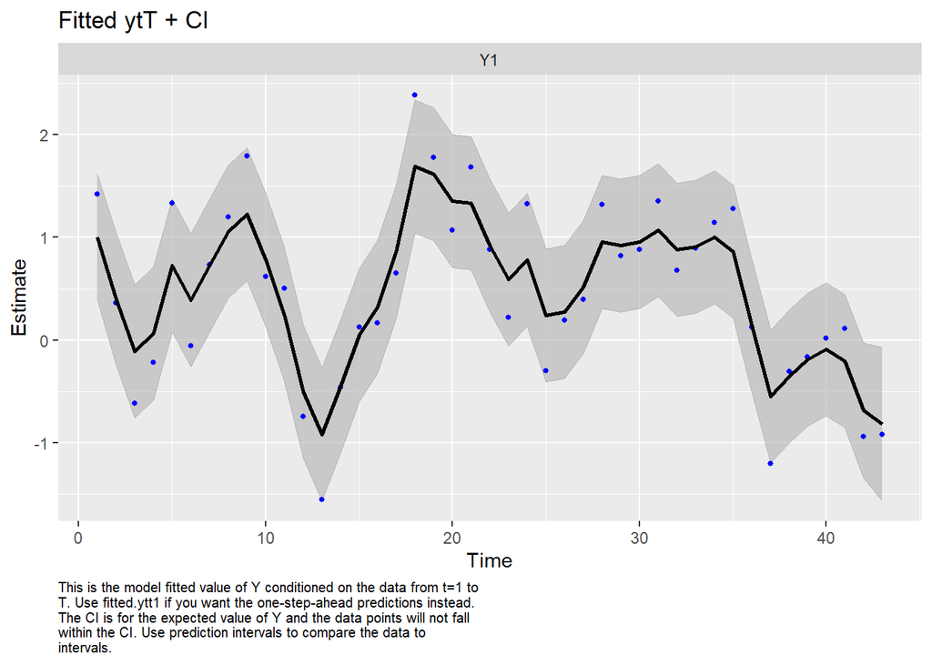

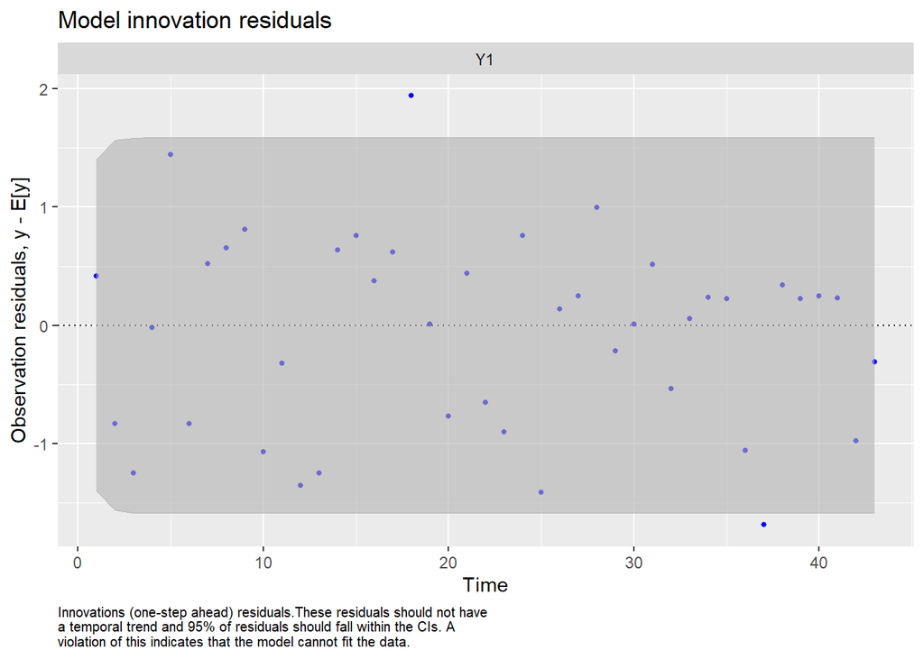

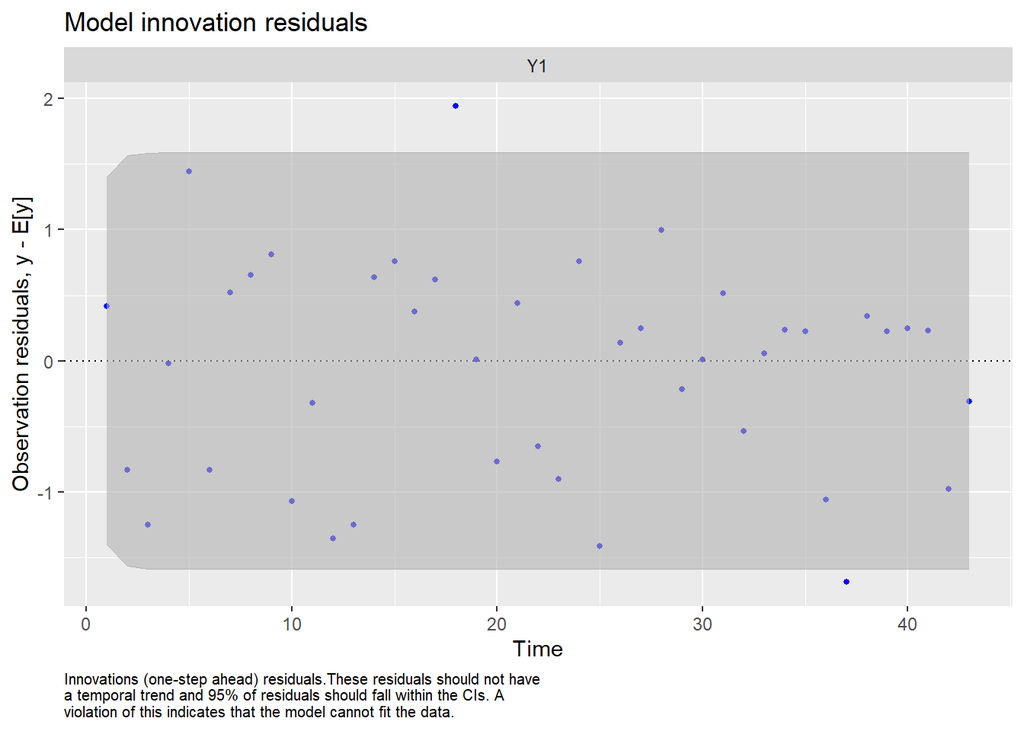

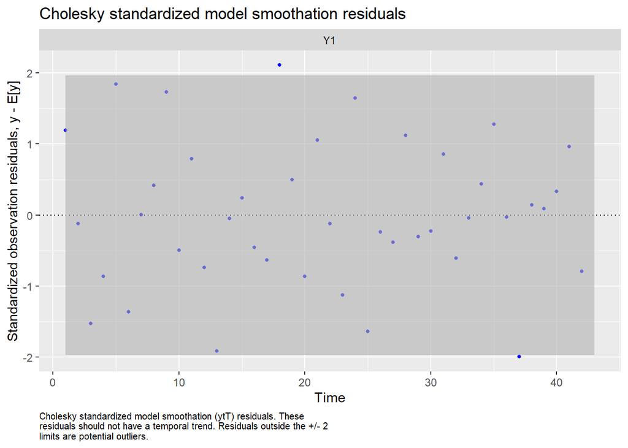

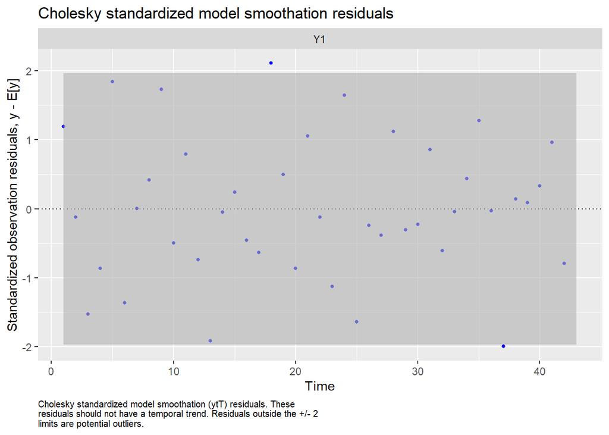

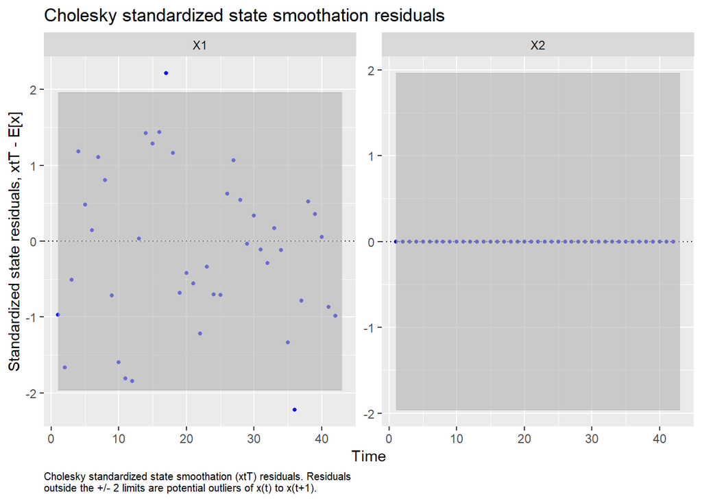

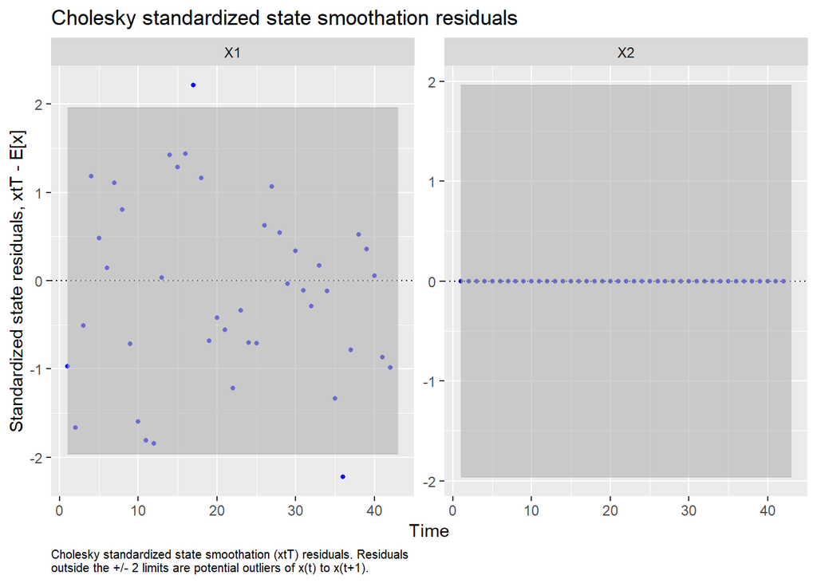

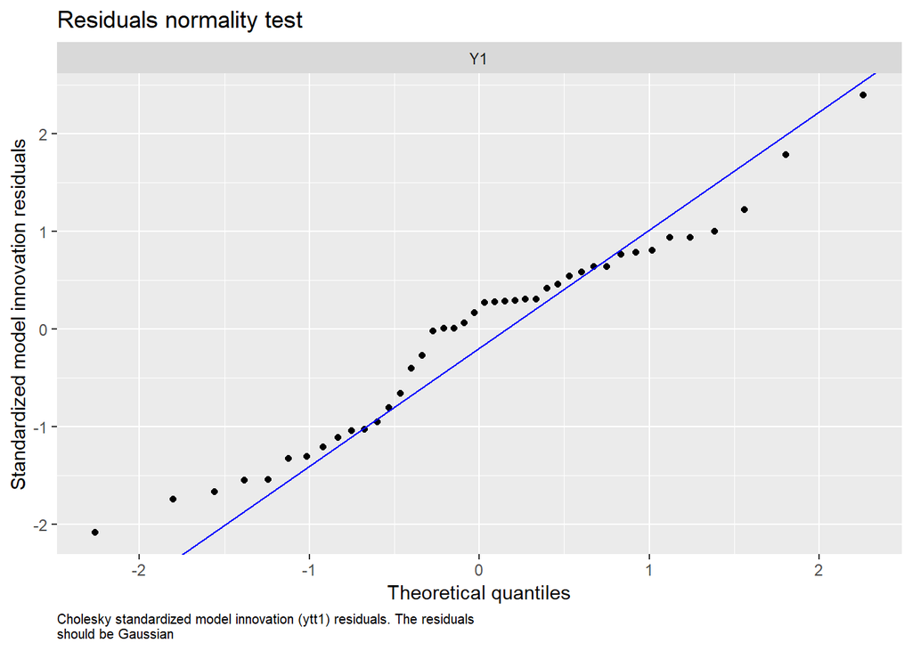

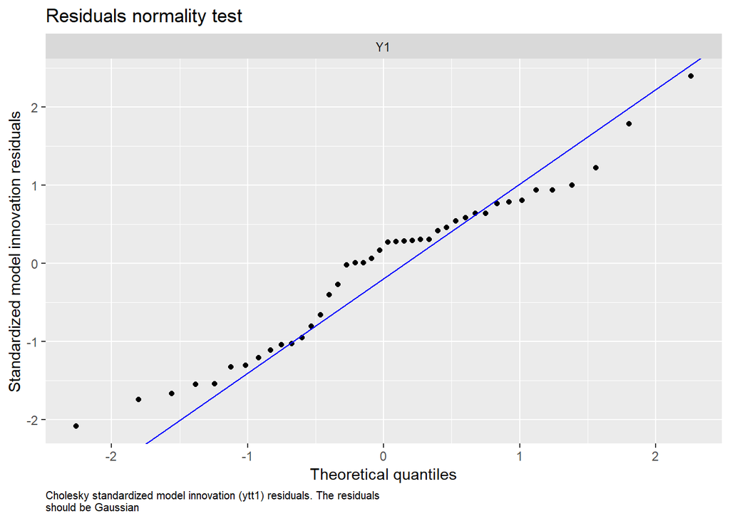

[4 more figures not shown]

```r
autoplot.marssMLE(full_Rick, silent = TRUE)
```

Results: Model fit, residuals, and ACF all look the same as the previous model because all the variation was loaded onto the intercept term.

## Full Ricker’s Model with Static Spawner Effect and Summer PDO covariate

3. Fit the expanded model that includes the summer PDO index as the covariate (`pdo_summer_t2`). What is the mean level of productivity? Plot the ts of $\delta_t$ and note the AICc for this model. Also plot appropriate model diagnostics.

$$\begin{align*}
\text{log}(R_t/S_t) = \alpha_t + \delta_t X_t - bS_t + v_t \\
\alpha_t = \alpha_{t-1} + w_t \\
\delta_t = \delta_{t-1} + w_t
\end{align*}$$

```r
#create the model params for the full Ricker's model
Z <- array(NA,c(1,3,TT)) # the array has 3 elements now
Z[1,1,] <- c(1)
Z[1,2,] <- SR_dat_short$spawners
Z[1,3,] <- SR_dat_short$pdo_summer_t2 # Covariate data is added to the Z matrix
# The model states are the covariate effects in a DLM

modlist <- list( # All other arguments are left as default
  Z = Z,
  U = "zero",
  A = "zero",
  B = "identity",
  Q = ldiag(list("q1",0,"q3")) # creates a custom Q matrix with zero variance for the spawner effect... I think? Additionally, the intercept variance may need to be contrained further
)

summer_Rick <- MARSS(Yt, model = modlist, control = list(maxit=1000), inits = list(x0 = matrix(c(1,1,1),3,1))) # added inits list due to marss error
```

```
## Success! abstol and log-log tests passed at 742 iterations.
## Alert: conv.test.slope.tol is 0.5.
## Test with smaller values (<0.1) to ensure convergence.
##
## MARSS fit is
## Estimation method: kem
## Convergence test: conv.test.slope.tol = 0.5, abstol = 0.001
## Estimation converged in 742 iterations.
## Log-likelihood: -51.78324
## AIC: 115.5665   AICc: 117.8998
##
##       Estimate
## R.R   2.00e-01
## Q.q1  3.16e-01
## Q.q3  0.00e+00
## x0.X1 1.01e+00
## x0.X2 5.49e-06
## x0.X3 2.85e-02
## Initial states (x0) defined at t=0
##
## Standard errors have not been calculated.
## Use MARSSparamCIs to compute CIs and bias estimates.
```

Result: AICC is 117.89, higher than the previous models and all the variance is loaded onto the intercept again. I have tried to limit the variation of the intercept but I get a MARSS error every time. I have also tried to change the initial values bu the resulting model was the same.